# 03_results_assessprocess

- Show All Code
- Hide All Code
- View Source

Supporting notebook to analyse the results of assessment process to uncover the reasons behind disagreements found among assessors, so that the AGILE Reproducibility Guidelines and the Assessemnt Protocol can be updated accordingly. See the **Results** section in the final article.

## Introduction

The majority of the work happened during the assessment process: evaluation of the papers, consolidation of the assessments, and **synthesis of the rich feedback** as well as interpretation of the findings. Here, we retrieve data items required to explore feedback from assessors during the assessment process. Individual scores of conceptual paper, data, methods, and results (computational environment is skipped, as it is not relevant for discrepancies analysis), notes from the two assessors (A1 and A2), and **type of disagreement** are relevant here.

```r
library(here)
library(tidyverse)
library(dplyr)
library(scales)
library(stringr)
library(gt)
library(ggplot2)
```

```r
assessment <-
  readr::read_csv(here::here("data-clean", "all-data.csv"))

assessment <-
  assessment |>
  dplyr::select(conf, paper, year,
                rev1, rev1_cp, rev1_data, rev1_methods, rev1_results, rev1_notes,
                rev2, rev2_cp, rev2_data, rev2_methods, rev2_results, rev2_notes,
                disagr_type, disagr_id) |>
  dplyr::arrange(conf, year)
```

Selected/relevant columns are: conf, paper, year, rev1, rev1_cp, rev1_data, rev1_methods, rev1_results, rev1_notes, rev2, rev2_cp, rev2_data, rev2_methods, rev2_results, rev2_notes, disagr_type, disagr_id. More details [here](https://github.com/nuest/reproducible-research-giscience-longitudinal-study/tree/main/data-clean).

```r
n_papers <- nrow(assessment)
n_papers_agile <-
  assessment |>
  count(conf) |>
  filter(conf == "agile") |>
  pull(n)


n_papers_giscience <-
  assessment |>
  count(conf) |>
  filter(conf == "giscience") |>
  pull(n)
```

## Types of disagreements

### Overview: all disagreement types together

These are the types of disagreements (`disagr_type`) between the individual reviewers’ scores.

- **no disagreement**: Assessors’ scores are the same in all dimensions (conceptual paper, data, methods, results)
- **borderline conceptual paper**: Disagreement are due to a different understanding whether a paper is completely conceptual; some assessors may see a paper that only has demonstrative, synthetic example data as not “data-based” or empirical and exclude it from the assessment.
- **annotation inconsistencies**: Disagreements are due to errors in the level/score selected given the written notes of either assessor. No matter the dimension where inconsistencies are.
- **uncertain assessment (according to protocol assessment)**: either assessor wrote that they are unsure about level x or y, so we could just change that to the level matching the other assessor
- **significant disagreement**: when assessors’ notes (or lack of notes) cannot explain differences in assessment and conversation to get an agreement is necessary and/or checking again the paper is required.

Table 1 below corresponds to the **Table 3: Distribution of disagreement types** of the published paper.

```r
assessment |>
  dplyr::count(disagr_type) |>
  dplyr::mutate(p = n /sum(n)) |>
  dplyr::arrange(desc(n)) |>
  gt::gt() |>
  gt::tab_header(
    title = "Distribution of disagreement types",
    subtitle = stringr::str_glue("No grouping (N={n_papers}). Table 3 of the published paper")
  ) |>
  gt::grand_summary_rows(
    columns = c("n","p"),
    fns = list(
      label = md("**Total**"),
      fn = "sum")
  ) |>
  gt::fmt_percent(
    columns = p,
    decimals = 1
  ) |>
  gt::cols_label(
    disagr_type = md("**Disagreement type**"),
    n = md("**#**"),
    p = md("**%**")
  )
```

Table 1: Distribution of disagreement types

Distribution of disagreement types

No grouping (N=224). Table 3 of the published paper

|  | **Disagreement type** | **#** | **%** |
| --- | --- | --- | --- |
|  | uncertain assessment | 100 | 44.6% |
|  | no disagreement | 63 | 28.1% |
|  | significant disagreement | 42 | 18.8% |
|  | borderline conceptual paper | 14 | 6.2% |
|  | annotation inconsistencies | 5 | 2.2% |
| **Total** | — | 224 | 1 |

```r
assessment |>
  dplyr::count(disagr_type) |>
  dplyr::mutate(p = n /sum(n)) |>
  dplyr::slice_max(order_by = p, n = 1) |>
  pull(p) -> p_disagr_top1

assessment |>
  dplyr::count(disagr_type) |>
  dplyr::mutate(p = n /sum(n)) |>
  dplyr::filter(disagr_type != "no disagreement") |> # Exclude agreement, of course
  dplyr::slice_max(order_by = p, n = 2) |>
  dplyr::summarize(sum = sum(p)) |>
  dplyr::pull(sum) -> p_disagr_top2

assessment |>
  dplyr::count(disagr_type) |>
  dplyr::mutate(p = n /sum(n)) |>
  dplyr::filter(disagr_type == "no disagreement") |> # Only total agreement
  dplyr::pull(p) -> p_no_disagr
```

First, the assessors made the same assessment in **28.1%** of the papers. Assessors disagreed in more than 70% of the total number of papers (N=224)!

Second, Table 1 also shows that, after excluding `no disagreement` (well, it means perfect match between assessors!), the two most common disagreement types cover (**63.4%**). Uncertainty in the application/interpretation of the assessment criteria covers a large proportion of the disagreements (**44.6%**), so there is room to improve and clarify aspects of the *Assessment Protocol* document to avoid slightly different interpretations of how the evaluation criteria have to be applied.

```r
assessment |>
  dplyr::group_by(conf) |>
  dplyr::count(disagr_type) |>
  dplyr::mutate(p = n /sum(n)) |>
  dplyr::arrange(conf, desc(n)) |>
  gt::gt() |>
  gt::tab_header(
    title = "Distribution of disagreement types",
    subtitle = stringr::str_glue("Grouped by conference (N={n_papers})")
  ) |>
  gt::fmt_percent(
    columns = p,
    decimals = 1
  ) |>
  gt::summary_rows(
    groups = everything(),
    columns = n,
    fns = list(
      total = "sum"
    )
  ) |>
  gt::cols_label(
    disagr_type = "",
    n = md("**#**"),
    p = md("**%**")
  )
```

Table 2: Distribution of disagreement types per conference: AGILE vs GIScience

Distribution of disagreement types

Grouped by conference (N=224)

|  |  | **#** | **%** |
| --- | --- | --- | --- |
| agile |  |  |  |
|  | uncertain assessment | 65 | 44.5% |
|  | no disagreement | 40 | 27.4% |
|  | significant disagreement | 30 | 20.5% |
|  | borderline conceptual paper | 8 | 5.5% |
|  | annotation inconsistencies | 3 | 2.1% |
| sum | — | 146 | — |
| giscience |  |  |  |
|  | uncertain assessment | 35 | 44.9% |
|  | no disagreement | 23 | 29.5% |
|  | significant disagreement | 12 | 15.4% |
|  | borderline conceptual paper | 6 | 7.7% |
|  | annotation inconsistencies | 2 | 2.6% |
| sum | — | 78 | — |

In general, Table 2 shows no remarkable differences between disagreement types per conference. Let’s focus on the three intermediate disagreement types which have different percentages. AGILE papers present greater percentage of `significant disagreement`, while GIScience papers have more papers assigned to `borderline conceptual paper` and `no disagreement`. Speculating a bit, we can say that GIScience papers tend to be more theoretical than AGILE articles, which are typically classified as applied research or application papers. Following this line of argument, GIScience papers may be much easier to evaluate than AGILE papers, in which greater uncertainty may arise when scoring the level of reproducibility for *Data*, *Methods*, and *Results*. That is, more theoretical papers often use fewer computational methods and data artifacts than applied research papers, so it makes sense that `borderline conceptual paper` and `no disagreement` are common disagreement types in theory-oriented papers. Therefore, the nature of research (I mean, the number of theory-oriented papers vs the number of application-oriented papers) between the two conferences could be one of the factor that explain these small, but still significant, differences in `no disagreement`, `significant disagreement`, and `borderline conceptual paper`.

```r
disagr_agile <-
  assessment |>
  dplyr::filter(conf =="agile") |>
  dplyr::group_by(year) |>
  dplyr::count(disagr_type) |>
  dplyr::mutate(p = n /sum(n)) |>
  dplyr::arrange(year, desc(n))


disagr_agile |>
  gt::gt() |>
  gt::tab_header(
    title = stringr::str_glue("AGILE conference only (N={n_papers_agile})")
  ) |>
  gt::fmt_percent(
    columns = p,
    decimals = 1
  ) |>
  gt::cols_label(
    disagr_type = "",
    year = md("Year"),
    n = md("**#**"),
    p = md("**%**")
  )
disagr_giscience <-
  assessment |>
  dplyr::filter(conf =="giscience") |>
  dplyr::group_by(year) |>
  dplyr::count(disagr_type) |>
  dplyr::mutate(p = n /sum(n)) |>
  dplyr::arrange(year, desc(n))

disagr_giscience |>
  gt::gt() |>
  gt::tab_header(
    title = stringr::str_glue("GIScience conference only (N={n_papers_giscience})")
  ) |>
  gt::fmt_percent(
    columns = p,
    decimals = 1
  ) |>
  gt::cols_label(
    disagr_type = "",
    year = md("Year"),
    n = md("**#**"),
    p = md("**%**")
  )
```

Table 3: Distribution of disagreement types per conference and year

(a) AGILE

AGILE conference only (N=146)

|  | **#** | **%** |
| --- | --- | --- |
| 2017 |  |  |
| no disagreement | 10 | 50.0% |
| significant disagreement | 4 | 20.0% |
| borderline conceptual paper | 3 | 15.0% |
| uncertain assessment | 3 | 15.0% |
| 2018 |  |  |
| significant disagreement | 9 | 47.4% |
| no disagreement | 5 | 26.3% |
| uncertain assessment | 5 | 26.3% |
| 2019 |  |  |
| uncertain assessment | 9 | 47.4% |
| no disagreement | 5 | 26.3% |
| significant disagreement | 4 | 21.1% |
| borderline conceptual paper | 1 | 5.3% |
| 2020 |  |  |
| uncertain assessment | 13 | 59.1% |
| no disagreement | 5 | 22.7% |
| annotation inconsistencies | 2 | 9.1% |
| borderline conceptual paper | 2 | 9.1% |
| 2021 |  |  |
| significant disagreement | 7 | 43.8% |
| no disagreement | 4 | 25.0% |
| uncertain assessment | 4 | 25.0% |
| annotation inconsistencies | 1 | 6.2% |
| 2022 |  |  |
| uncertain assessment | 15 | 68.2% |
| no disagreement | 5 | 22.7% |
| significant disagreement | 2 | 9.1% |
| 2023 |  |  |
| uncertain assessment | 9 | 64.3% |
| no disagreement | 3 | 21.4% |
| borderline conceptual paper | 1 | 7.1% |
| significant disagreement | 1 | 7.1% |
| 2024 |  |  |
| uncertain assessment | 7 | 50.0% |
| no disagreement | 3 | 21.4% |
| significant disagreement | 3 | 21.4% |
| borderline conceptual paper | 1 | 7.1% |

(b) GIScience

GIScience conference only (N=78)

|  | **#** | **%** |
| --- | --- | --- |
| 2016 |  |  |
| no disagreement | 10 | 47.6% |
| uncertain assessment | 6 | 28.6% |
| borderline conceptual paper | 3 | 14.3% |
| significant disagreement | 2 | 9.5% |
| 2018 |  |  |
| uncertain assessment | 7 | 41.2% |
| no disagreement | 6 | 35.3% |
| significant disagreement | 3 | 17.6% |
| borderline conceptual paper | 1 | 5.9% |
| 2020 |  |  |
| uncertain assessment | 10 | 62.5% |
| no disagreement | 2 | 12.5% |
| significant disagreement | 2 | 12.5% |
| annotation inconsistencies | 1 | 6.2% |
| borderline conceptual paper | 1 | 6.2% |
| 2021 |  |  |
| uncertain assessment | 7 | 53.8% |
| no disagreement | 4 | 30.8% |
| annotation inconsistencies | 1 | 7.7% |
| significant disagreement | 1 | 7.7% |
| 2023 |  |  |
| uncertain assessment | 5 | 45.5% |
| significant disagreement | 4 | 36.4% |
| borderline conceptual paper | 1 | 9.1% |
| no disagreement | 1 | 9.1% |

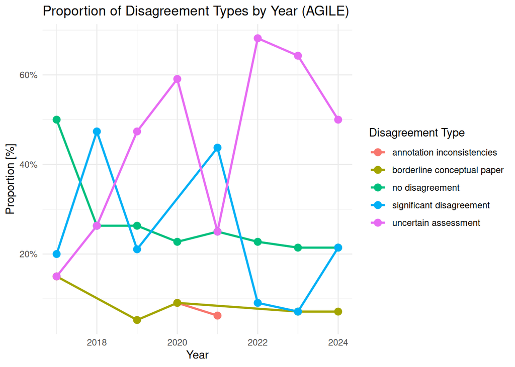

(a) AGILE

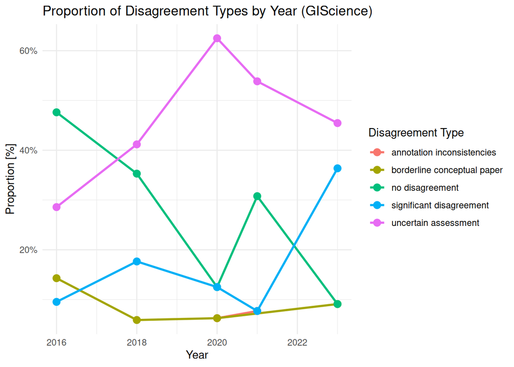

(b) GIScience

Figure 1: Distribution of disagreement types per conference and year (plots)

```r
disagrLinePlot <- function(data, main) {
  ggplot2::ggplot(data,
                  aes(x = year, y = p, color = disagr_type)) +
  ggplot2::geom_line(linewidth = 1) +
  ggplot2::geom_point(size = 3) +
  ggplot2::scale_y_continuous(labels = scales::percent_format(accuracy = 1)) +  # Format y-axis as %
  ggplot2::guides(
      color = guide_legend(ncol = 1, position = "right")) +
  ggplot2::labs(
    title = main,
    x = "Year",
    y = "Proportion [%]",
    color = "Disagreement Type"
  ) +
  ggplot2::theme_minimal()

}


fig_agile <- disagrLinePlot(disagr_agile, "Proportion of Disagreement Types by Year (AGILE)")
fig_giscience <- disagrLinePlot(disagr_giscience, "Proportion of Disagreement Types by Year (GIScience)")

fig_agile
fig_giscience
```

Looking into the data over years, Table 3 breaks disagreement types per conference and year. Figure 1 represents the same data as line charts.

- `borderline conceptual paper` disagreements follow similar trend in both conferences. It is almost residual in recent years (1 paper per year/conference). It was different in the first year of the series (AGILE 2017, GIScience 2016) where more disagreements of this type occurred.
- `annotation inconsistencies` is residual.
- `no disagreement`, `uncertain assessment` and `significant disagreement` appear to be somewhat related. In general, when `no disagreement` increases, the other two decrease. And viceversa.
- `no disagreement` tends to decrease over time in both conferences, suggesting that agreement between assessors in assessing the level of reproducibility in the first years of the series (AGILE 2017, GIScience 2026, GIScience 2018) was *much easier* than in recent years. Why? Possible reasons:
  - Authors have increasingly adopted best practices for describing or including other research resources used in their articles, which were often omitted in articles in earlier conferences.
  - The number of computational papers at recent conferences tends to be higher than in previous years.
- `uncertain assessment` and `significant disagreement`. Together, it is hard to interpret them. Well, a pattern is visible over the last three conference editions: From a maximum peak (AGILE 2022, GIScience 2020), percentage of `uncertain assessment` decreases while that of `significant disagreement` increases for both conferences. Yet, the increase of `significant disagrement` is greater in the last GIScience conference. Why: Perhaps the lack of explicit reproducibility guidelines for GIScience authors may have a factor as the number of computational papers in GIScience goes up.

### Top3 types of discrepancies: `no disagreement`, `uncertain assessment` and `significant disagreement`

```r
top3 = c("no disagreement", "uncertain assessment", "significant disagreement")

disagr_agile |>
  dplyr::filter(disagr_type %in% top3) |>
  dplyr::select(-n) |>
  tidyr::pivot_wider(
    names_from = "disagr_type",
    values_from = "p") |>
  dplyr::ungroup() |>
  gt::gt() |>
  gt::tab_header(
    title = stringr::str_glue("AGILE conference only (N={n_papers_agile})")
  ) |>
  gt::tab_spanner(
    label = "3-top disagreement types",
    columns = top3
  ) |>
  gt::fmt_percent(
    columns = c(everything(), -year),
    decimals = 1
  ) |>
  gt::data_color(
    columns = c(everything(), -year),
    method = "bin",
    palette = "RdBu",
    reverse = TRUE
  )
disagr_giscience |>
  dplyr::filter(disagr_type %in% top3) |>
  dplyr::select(-n) |>
  tidyr::pivot_wider(
    names_from = "disagr_type",
    values_from = "p") |>
  dplyr::ungroup() |>
  gt::gt() |>
  gt::tab_header(
    title = stringr::str_glue("GIScience conference only (N={n_papers_giscience})")
  ) |>
  gt::tab_spanner(
    label = "3-top disagreement types",
    columns = top3
  ) |>
  gt::fmt_percent(
    columns = c(everything(), -year),
    decimals = 1
  ) |>
  gt::data_color(
    columns = c(everything(), -year),
    method = "bin",
    palette = "RdBu",
    reverse = TRUE
  )
```

Table 4: Distribution of 3-top disagreement types per conference and year

(a) AGILE

AGILE conference only (N=146)

| year | 3-top disagreement types no disagreement | 3-top disagreement types uncertain assessment | 3-top disagreement types significant disagreement |
| --- | --- | --- | --- |
| 2017 | 50.0% | 15.0% | 20.0% |
| 2018 | 26.3% | 26.3% | 47.4% |
| 2019 | 26.3% | 47.4% | 21.1% |
| 2020 | 22.7% | 59.1% | NA |
| 2021 | 25.0% | 25.0% | 43.8% |
| 2022 | 22.7% | 68.2% | 9.1% |
| 2023 | 21.4% | 64.3% | 7.1% |
| 2024 | 21.4% | 50.0% | 21.4% |

(b) GIScience

GIScience conference only (N=78)

| year | 3-top disagreement types no disagreement | 3-top disagreement types uncertain assessment | 3-top disagreement types significant disagreement |
| --- | --- | --- | --- |
| 2016 | 47.6% | 28.6% | 9.5% |
| 2018 | 35.3% | 41.2% | 17.6% |
| 2020 | 12.5% | 62.5% | 12.5% |
| 2021 | 30.8% | 53.8% | 7.7% |
| 2023 | 9.1% | 45.5% | 36.4% |

Table 4 corresponds to the **Figure 2: Distribution of 3-top disagreement types per conference and year** of the published paper. And Table 4 “zooms in” Table 3 to show in detail the 3-top types of disagreement.

## Looking at individdual types of disagreements

We explore the scores (data, methods, and results) of the two reviewers for each type of disagreement, excluding `no disagrement`, `borderline conceptual paper`, and `annotation inconsistencies`.

### Type: `uncertain assessment`

```r
curr_type = "uncertain assessment"

n_disagr_uncertain <-
  assessment |>
  filter(disagr_type == curr_type) |>
  count() |>
  pull(n)

n_disagr_uncertain_agile <-
  assessment |>
  filter(conf == "agile", disagr_type == curr_type) |>
  count() |>
  pull(n)

n_disagr_uncertain_giscience <-
  assessment |>
  filter(conf == "giscience", disagr_type == curr_type) |>
  count() |>
  pull(n)


disagr_uncertain <-
  assessment |>
  dplyr::select(-paper, -rev1, -rev2, -rev1_cp, -rev2_cp, -rev1_notes, -rev2_notes) |>
  dplyr::filter(disagr_type == curr_type) |>
  dplyr::mutate(disagr_dat = case_when(
    is.na(rev1_data) ~ TRUE,
    is.na(rev2_data) ~ TRUE,
    .default = (rev1_data != rev2_data))) |>
  dplyr::mutate(disagr_met = case_when(
    is.na(rev1_methods) ~ TRUE,
    is.na(rev2_methods) ~ TRUE,
    .default =(rev1_methods != rev2_methods))) |>
  dplyr::mutate(disagr_res = case_when(
    is.na(rev1_results) ~ TRUE,
    is.na(rev2_results) ~ TRUE,
    .default = (rev1_results != rev2_results)))
```

```r
data_tbl_disagr_uncertain <-
  bind_cols(
    disagr_uncertain |>
    dplyr::group_by(conf, disagr_dat) |>
    dplyr::count(name = "n_dat") |>
    dplyr::ungroup(disagr_dat) |>
    dplyr::mutate(p_dat = n_dat / sum(n_dat)) |>
    dplyr::ungroup(),

    disagr_uncertain |>
    dplyr::group_by(conf, disagr_met) |>
    dplyr::count(name = "n_met") |>
    dplyr::ungroup(disagr_met) |>
    dplyr::mutate(p_met = n_met / sum(n_met)) |>
    dplyr::ungroup() |>
    dplyr::select(-conf),

    disagr_uncertain |>
    dplyr::group_by(conf, disagr_res) |>
    dplyr::count(name = "n_res") |>
    dplyr::ungroup(disagr_res) |>
    dplyr::mutate(p_res = n_res / sum(n_res)) |>
    dplyr::ungroup() |>
    dplyr::select(-conf)
  )


tbl_disagr_uncertain <-
  data_tbl_disagr_uncertain |>
  dplyr::mutate(conf = stringr::str_to_upper(conf)) |>
  gt::gt() |>
  gt::tab_header(
    title = stringr::str_glue("Uncertain disagreement (N={n_disagr_uncertain})"),
    subtitle = md("Applied to *Input data*, *Methods, ...* and *Results* dimensions.")
  ) |>
  gt::tab_spanner(
    label = md("**Input Data**"),
    columns = ends_with("_dat"),
  ) |>
  gt::tab_spanner(
    label = md("**Methods, ...**"),
    columns = ends_with("_met"),
  ) |>
  gt::tab_spanner(
    label = md("**Results**"),
    columns = ends_with("_res"),
  ) |>
  gt::cols_align(
    align = c("center"),
    columns = everything()
  ) |>
  # Commented code for make table cells in bold.
  #gt::tab_style(
  #  style = cell_text(weight = "bold"),
  #  locations =
  #    cells_body(
  #      rows = disagr_dat == TRUE)
  #) |>
  # Commented code for coloring table cells. Replaced by footnotes (best for exporting to latex)
  #gt::tab_style(
  #  style = cell_fill(color = "lightcyan"),
  #  locations = list(
  #    cells_body(
  #      columns = p_met,
  #      rows = p_met <= 0.3),
  #    cells_body(
  #      columns = p_res,
  #      rows = p_res <= 0.2)
  #  )
  #) |>
  #gt::tab_style(
  #  style = list(
  #    cell_fill(color = "indianred"),
  #    cell_text(color = "white")
  #    ),
  #  locations = cells_body(
  #      columns = p_dat,
  #      rows = p_dat >= 0.6
  #  )
  #) |>
  gt::fmt_percent(
    columns = c(p_dat, p_met, p_res),
    decimals = 1
  ) |>
  gt::fmt_tf(
    columns = c(disagr_dat, disagr_met, disagr_res),
    tf_style = "yes-no"
  ) |>
  gt::cols_label(
    conf = md("*Conf Series*"),
    disagr_dat = md("*Disagr?*"),
    disagr_met = md("*Disagr?*"),
    disagr_res = md("*Disagr?*"),
    n_dat = md("*#*"),
    p_dat = md("*%*"),
    n_met = md("*#*"),
    p_met = md("*%*"),
    n_res = md("*#*"),
    p_res = md("*%*"),
  ) |>
  gt::tab_style(
    style = cell_borders(sides = c("bottom"),  weight = px(1.5)),
    locations = cells_body(rows = 2)
  ) |>
  gt::opt_align_table_header(align = "center") |>
  gt::tab_footnote(
    footnote = "Major disagreements at both conferences.",
    locations = cells_body(columns = p_dat, rows = c(2, 4))
  ) |>
  gt::tab_footnote(
    footnote = md("Minor disagreements at the AGILE conference."),
    locations = cells_body(columns = p_met, rows = 2)
  ) |>
  gt::tab_footnote(
    footnote = md("Minor disagreements at the GIScience conference."),
    locations = cells_body(columns = p_res, rows = 4)
  )
  #gt::tab_options(footnotes.multiline = FALSE)  # All footnotes as a single line.


tbl_disagr_uncertain
```

Table 5: Distribution of ‘Uncertain disagreement’

Uncertain disagreement (N=100)

Applied to *Input data*, *Methods, …* and *Results* dimensions.

| *Conf Series* | **Input Data** *Disagr?* | **Input Data** *#* | **Input Data** *%* | **Methods, …** *Disagr?* | **Methods, …** *#* | **Methods, …** *%* | **Results** *Disagr?* | **Results** *#* | **Results** *%* |
| --- | --- | --- | --- | --- | --- | --- | --- | --- | --- |
| AGILE | no | 23 | 35.4% | no | 46 | 70.8% | no | 36 | 55.4% |
| AGILE | yes | 42 | 64.6%<sup>1</sup> | yes | 19 | 29.2%<sup>2</sup> | yes | 29 | 44.6% |
| GISCIENCE | no | 7 | 20.0% | no | 24 | 68.6% | no | 28 | 80.0% |
| GISCIENCE | yes | 28 | 80.0%<sup>1</sup> | yes | 11 | 31.4% | yes | 7 | 20.0%<sup>3</sup> |

<sup>1</sup> Major disagreements at both conferences.  
<sup>2</sup> Minor disagreements at the AGILE conference.  
<sup>3</sup> Minor disagreements at the GIScience conference.

Table 5 corresponds to the **Table 4: Distribution of “uncertain assessment” (N=100) per conference and criterion** of the published paper.

What we observe in Table 5 (only rows with `disagr?` == `yes`) is:

- AGILE:
  - Lowest proportion of `uncertain assessment` disagreements is in **Methods**, under 30%.
  - Highest proportion of `uncertain assessment` disagreements is in **Input data**, close to 65%.
  - From higher to lower proportion of disagreements: Data -> Results -> Methods
- GIScience:
  - Lowest proportion of `uncertain assessment` disagreements is in **Results**, just 20%.
  - Highest proportion of `uncertain assessment` disagreements is in **Input data**, just 80%.
  - From higher to lower proportion of disagreements: Data -> Methods -> Results

In Figure 2, we look now at the individual scores (UDAO levels) for each of the dimensions (data, methods, results), considering AGILE (top row) and GIScience (bottom row).

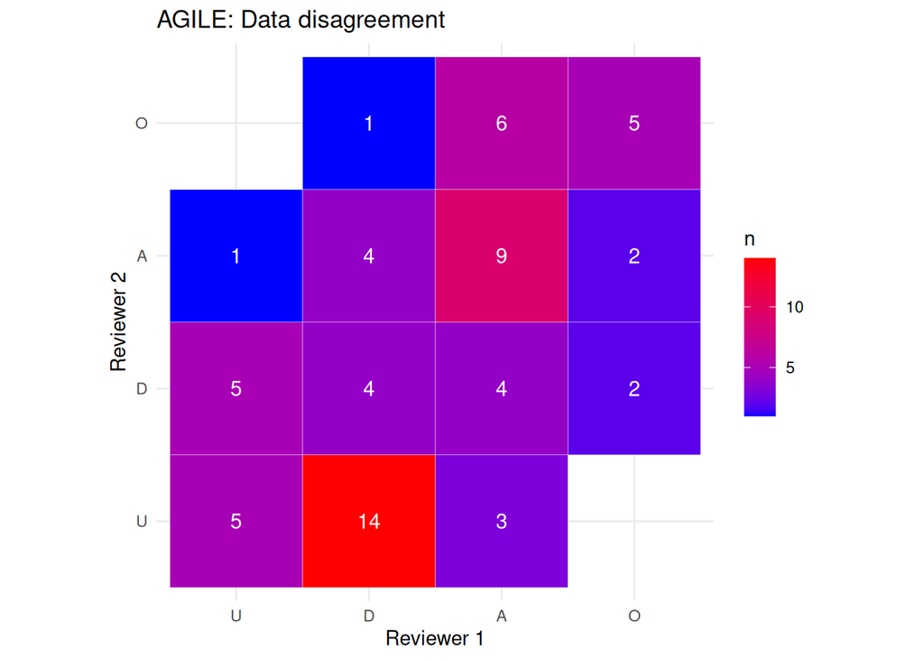

(a) AGILE: Data

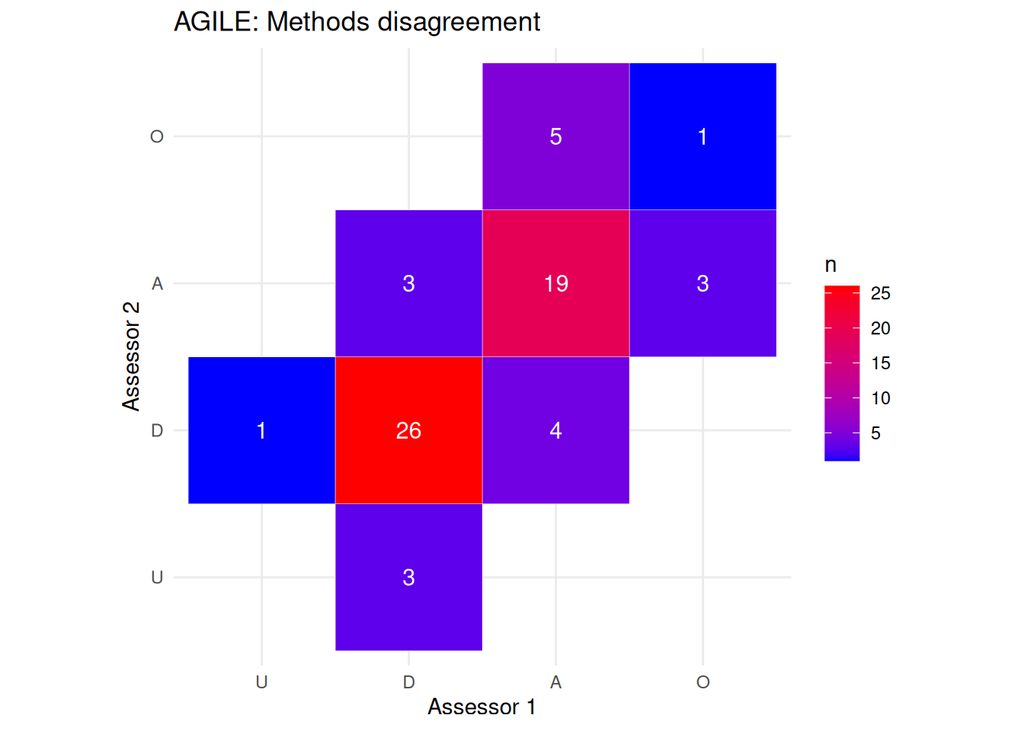

(b) AGILE: Methods

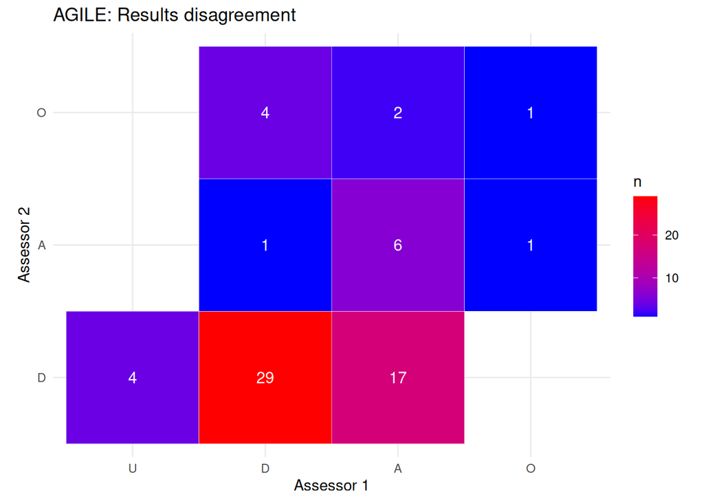

(c) AGILE: Results

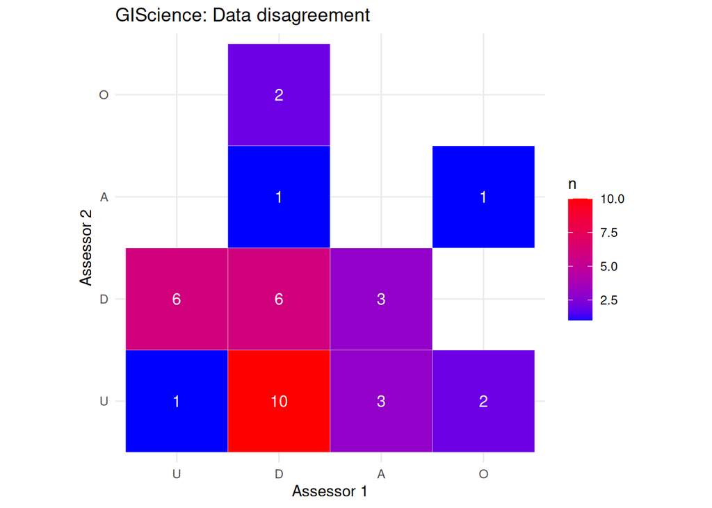

(d) GIScience: Data

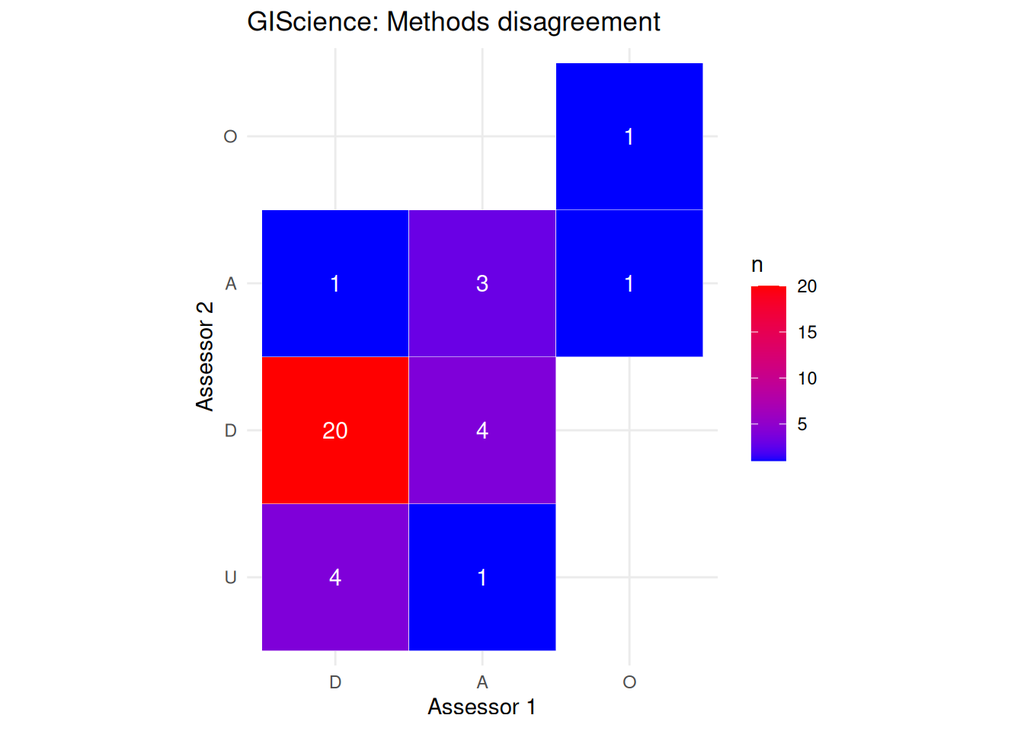

(e) GIScience: Methods

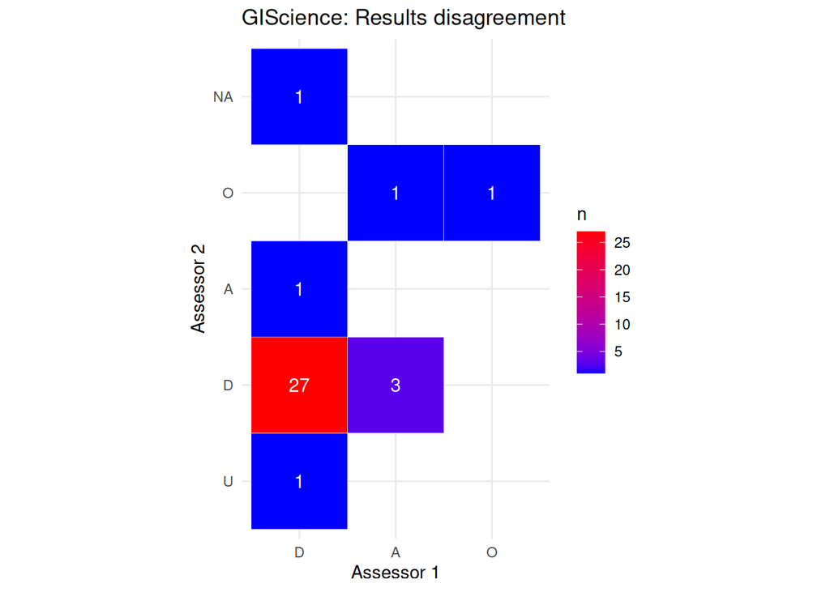

(f) GIScience: Results

Figure 2: Counts of UDAO scores for ‘uncertain disagreement’ between assessors (heatmap): AGILE vs GIScience

```r
# TODO: https://www.sthda.com/english/wiki/ggplot2-quick-correlation-matrix-heatmap-r-software-and-data-visualization

udao_levels <-  c("U", "D", "A", "O")

heatmap_agile_dat <-
  disagr_uncertain |>
    dplyr::filter(conf=="agile") |>
    dplyr::select(year, rev1_data, rev2_data) |>
    dplyr::mutate(rev1_data = factor(rev1_data, levels = udao_levels)) |>
    dplyr::mutate(rev2_data = factor(rev2_data, levels = udao_levels)) |>
    dplyr::group_by(rev1_data,rev2_data) %>%
    dplyr::tally()


heatmap_agile_met <-
  disagr_uncertain |>
    dplyr::filter(conf=="agile") |>
    dplyr::select(year, rev1_methods, rev2_methods) |>
    dplyr::mutate(rev1_methods = factor(rev1_methods, levels = udao_levels)) |>
    dplyr::mutate(rev2_methods  = factor(rev2_methods, levels = udao_levels)) |>
    dplyr::group_by(rev1_methods,rev2_methods) %>%
    dplyr::tally()


heatmap_agile_res <-
  disagr_uncertain |>
    dplyr::filter(conf=="agile") |>
    dplyr::select(year, rev1_results, rev2_results) |>
    dplyr::mutate(rev1_results = factor(rev1_results, levels = udao_levels)) |>
    dplyr::mutate(rev2_results = factor(rev2_results, levels = udao_levels)) |>
    dplyr::group_by(rev1_results,rev2_results) %>%
    dplyr::tally()


heatmap_giscience_dat <-
  disagr_uncertain |>
    dplyr::filter(conf=="giscience") |>
    dplyr::select(year, rev1_data, rev2_data) |>
    dplyr::mutate(rev1_data = factor(rev1_data, levels = udao_levels)) |>
    dplyr::mutate(rev2_data = factor(rev2_data, levels = udao_levels)) |>
    dplyr::group_by(rev1_data,rev2_data) %>%
    dplyr::tally()


heatmap_giscience_met <-
  disagr_uncertain |>
    dplyr::filter(conf=="giscience") |>
    dplyr::select(year, rev1_methods, rev2_methods) |>
    dplyr::mutate(rev1_methods = factor(rev1_methods, levels = udao_levels)) |>
    dplyr::mutate(rev2_methods  = factor(rev2_methods, levels = udao_levels)) |>
    dplyr::group_by(rev1_methods,rev2_methods) %>%
    dplyr::tally()


heatmap_giscience_res <-
  disagr_uncertain |>
    dplyr::filter(conf=="giscience") |>
    dplyr::select(year, rev1_results, rev2_results) |>
    dplyr::mutate(rev1_results = factor(rev1_results, levels = udao_levels)) |>
    dplyr::mutate(rev2_results = factor(rev2_results, levels = udao_levels)) |>
    dplyr::group_by(rev1_results,rev2_results) %>%
    dplyr::tally()


heatmap_agile_dat |>
  ggplot2::ggplot(aes(x = rev1_data, y = rev2_data, fill = n)) +
  ggplot2::geom_tile(color = "white") +
  ggplot2::geom_text(aes(label = n), color = "white", size = 4) +
  ggplot2::scale_fill_gradient(low = "blue", high = "red") +
  ggplot2::coord_fixed() +
  ggplot2::labs(title = "AGILE: Data disagreement",
       x = "Reviewer 1",
       y = "Reviewer 2") +
  ggplot2::theme_minimal()

heatmap_agile_met |>
  ggplot2::ggplot(aes(x = rev1_methods, y = rev2_methods, fill = n)) +
  ggplot2::geom_tile(color = "white") +
  ggplot2::geom_text(aes(label = n), color = "white", size = 4) +
  ggplot2::scale_fill_gradient(low = "blue", high = "red") +
  ggplot2::coord_fixed() +
  ggplot2::labs(title = "AGILE: Methods disagreement",
       x = "Assessor 1",
       y = "Assessor 2") +
  ggplot2::theme_minimal()


heatmap_agile_res |>
  ggplot2::ggplot(aes(x = rev1_results, y = rev2_results, fill = n)) +
  ggplot2::geom_tile(color = "white") +
  ggplot2::geom_text(aes(label = n), color = "white", size = 4) +
  ggplot2::scale_fill_gradient(low = "blue", high = "red") +
  ggplot2::coord_fixed() +
  ggplot2::labs(title = "AGILE: Results disagreement",
       x = "Assessor 1",
       y = "Assessor 2") +
  ggplot2::theme_minimal()


heatmap_giscience_dat |>
  ggplot2::ggplot(aes(x = rev1_data, y = rev2_data, fill = n)) +
  ggplot2::geom_tile(color = "white") +
  ggplot2::geom_text(aes(label = n), color = "white", size = 4) +
  ggplot2::scale_fill_gradient(low = "blue", high = "red") +
  ggplot2::coord_fixed() +
  ggplot2::labs(title = "GIScience: Data disagreement",
       x = "Assessor 1",
       y = "Assessor 2") +
  ggplot2::theme_minimal()

heatmap_giscience_met |>
  ggplot2::ggplot(aes(x = rev1_methods, y = rev2_methods, fill = n)) +
  ggplot2::geom_tile(color = "white") +
  ggplot2::geom_text(aes(label = n), color = "white", size = 4) +
  ggplot2::scale_fill_gradient(low = "blue", high = "red") +
  ggplot2::coord_fixed() +
  ggplot2::labs(title = "GIScience: Methods disagreement",
       x = "Assessor 1",
       y = "Assessor 2") +
  ggplot2::theme_minimal()


heatmap_giscience_res |>
  ggplot2::ggplot(aes(x = rev1_results, y = rev2_results, fill = n)) +
  ggplot2::geom_tile(color = "white") +
  ggplot2::geom_text(aes(label = n), color = "white", size = 4) +
  ggplot2::scale_fill_gradient(low = "blue", high = "red") +
  ggplot2::coord_fixed() +
  ggplot2::labs(title = "GIScience: Results disagreement",
       x = "Assessor 1",
       y = "Assessor 2") +
  ggplot2::theme_minimal()
```

### Type: `significant disagreement`

```r
curr_type = "significant disagreement"

n_disagr_significant <-
  assessment |>
  dplyr::filter(disagr_type == curr_type) |>
  dplyr::count() |>
  dplyr::pull(n)

n_disagr_significant_agile <-
  assessment |>
  dplyr::filter(conf == "agile", disagr_type == curr_type) |>
  dplyr::count() |>
  dplyr::pull(n)

n_disagr_significant_giscience <-
  assessment |>
  dplyr::filter(conf == "giscience", disagr_type == curr_type) |>
  dplyr::count() |>
  dplyr::pull(n)

disagr_significant <-
  assessment |>
  dplyr::select(-paper, -rev1, -rev2, -rev1_cp, -rev2_cp, -rev1_notes, -rev2_notes) |>
  dplyr::filter(disagr_type == curr_type) |>
  dplyr::mutate(disagr_dat = case_when(
    is.na(rev1_data) ~ TRUE,
    is.na(rev2_data) ~ TRUE,
    .default = (rev1_data != rev2_data))) |>
  dplyr::mutate(disagr_met = case_when(
    is.na(rev1_methods) ~ TRUE,
    is.na(rev2_methods) ~ TRUE,
    .default = (rev1_methods != rev2_methods))) |>
  dplyr::mutate(disagr_res = case_when(
    is.na(rev1_results) ~ TRUE,
    is.na(rev2_results) ~ TRUE,
    .default = (rev1_results != rev2_results)))
```

```r
data_tbl_disagr_significant <-
  bind_cols(
    disagr_significant |>
    dplyr::group_by(conf, disagr_dat) |>
    dplyr::count(name = "n_dat") |>
    dplyr::ungroup(disagr_dat) |>
    dplyr::mutate(p_dat = n_dat / sum(n_dat)) |>
    dplyr::ungroup(),

    disagr_significant |>
    dplyr::group_by(conf, disagr_met) |>
    dplyr::count(name = "n_met") |>
    dplyr::ungroup(disagr_met) |>
    dplyr::mutate(p_met = n_met / sum(n_met)) |>
    dplyr::ungroup() |>
    dplyr::select(-conf),

    disagr_significant |>
    dplyr::group_by(conf, disagr_res) |>
    dplyr::count(name = "n_res") |>
    dplyr::ungroup(disagr_res) |>
    dplyr::mutate(p_res = n_res / sum(n_res)) |>
    dplyr::ungroup() |>
    dplyr::select(-conf)
  )

tbl_disagr_significant <-
  data_tbl_disagr_significant |>
  dplyr::mutate(conf = stringr::str_to_upper(conf)) |>
  gt::gt() |>
  gt::tab_header(
    title = stringr::str_glue("Significant disagreement (N={n_disagr_significant})"),
    subtitle = md("Applied to *Input data*, *Methods,...* and *Results* dimensions.")
  ) |>
  gt::tab_spanner(
    label = md("**Input data**"),
    columns = ends_with("_dat"),
  ) |>
  gt::tab_spanner(
    label = md("**Methods,...**"),
    columns = ends_with("_met"),
  ) |>
  gt::tab_spanner(
    label = md("**Results**"),
    columns = ends_with("_res"),
  ) |>
  gt::cols_align(
    align = c("center"),
    columns = everything()
  ) |>
  # Commented code for make table cells in bold.
  #gt::tab_style(
  #  style = cell_text(weight = "bold"),
  #  locations =
  #    cells_body(
  #      rows = disagr_dat == TRUE)
  #) |>
  # Commented code for coloring table cells. Replaced by footnotes (best for exporting to latex)
  #gt::tab_style(
  #  style = list(
  #    cell_fill(color = "indianred"),
  #    cell_text(color = "white")
  #    ),
  #  locations = cells_body(
  #      columns = p_dat,
  #      rows = p_dat >= 0.7
  #  )
  #) |>
  gt::fmt_percent(
    columns = c(p_dat, p_met, p_res),
    decimals = 1
  ) |>
  gt::fmt_tf(
    columns = c(disagr_dat, disagr_met, disagr_res),
    tf_style = "yes-no"
  ) |>
  gt::cols_label(
    conf = md("*Conf Series*"),
    disagr_dat = md("*Disagr?*"),
    disagr_met = md("*Disagr?*"),
    disagr_res = md("*Disagr?*"),
    n_dat = md("*#*"),
    p_dat = md("*%*"),
    n_met = md("*#*"),
    p_met = md("*%*"),
    n_res = md("*#*"),
    p_res = md("*%*"),
  ) |>
  gt::tab_style(
    style = cell_borders(sides = c("bottom"),  weight = px(1.5)),
    locations = cells_body(rows = 2)
  ) |>
  gt::opt_align_table_header(align = "center") |>
  gt::tab_footnote(
    footnote = "Major disagreements at both conferences.",
    locations = cells_body(columns = p_dat, rows = c(2, 4))
  ) |>
  gt::tab_footnote(
    footnote = md("Minor disagreements at the AGILE conference."),
    locations = cells_body(columns = p_res, rows = 2)
  ) |>
  gt::tab_footnote(
    footnote = md("Minor disagreements at the GIScience conference."),
    locations = cells_body(columns = c(p_met, p_res), rows = 4)
  )

  #gt::tab_options(footnotes.multiline = FALSE)  # All footnotes as a single line.


tbl_disagr_significant
```

Table 6: Distribution of ‘significant disagreement’

Significant disagreement (N=42)

Applied to *Input data*, *Methods,…* and *Results* dimensions.

| *Conf Series* | **Input data** *Disagr?* | **Input data** *#* | **Input data** *%* | **Methods,…** *Disagr?* | **Methods,…** *#* | **Methods,…** *%* | **Results** *Disagr?* | **Results** *#* | **Results** *%* |
| --- | --- | --- | --- | --- | --- | --- | --- | --- | --- |
| AGILE | no | 6 | 20.0% | no | 9 | 30.0% | no | 13 | 43.3% |
| AGILE | yes | 24 | 80.0%<sup>1</sup> | yes | 21 | 70.0% | yes | 17 | 56.7%<sup>2</sup> |
| GISCIENCE | no | 3 | 25.0% | no | 5 | 41.7% | no | 5 | 41.7% |
| GISCIENCE | yes | 9 | 75.0%<sup>1</sup> | yes | 7 | 58.3%<sup>3</sup> | yes | 7 | 58.3%<sup>3</sup> |

<sup>1</sup> Major disagreements at both conferences.  
<sup>2</sup> Minor disagreements at the AGILE conference.  
<sup>3</sup> Minor disagreements at the GIScience conference.

Table 6 corresponds to the **Table 5: Distribution of “significant disagreement” (N=42) per conference and criterion** of the published paper.

What we observe in Table 6 (only rows with `Disagr?` == `yes`) is:

- AGILE:
  - Lowest proportion of `major disagreement` is in **Results**.
  - Highest proportion of `major disagreement` is in **Data**.
  - From higher to lower proportion of disagreements: Data -> Methods -> Results
- GIScience:
  - Lowest proportion of `major disagreement` is in **Methods and Results**, same proportion.
  - Highest proportion of `uncertain disagreement` is in **Data**.
  - From higher to lower proportion of disagreements: Data -> Methods/Results